# Campaigning for subsidy allocation

Jie Li

11/3/2021

```r
library(tidyverse)
library(sf)
library(RSocrata)
library(viridis)
library(spatstat)
library(raster)
library(spdep)
library(FNN)
library(grid)
library(gridExtra)
library(knitr)
library(kableExtra)
library(tidycensus)
library(gtable)
library(ggpubr)
library(caret)
library(knitr)
library(pscl)
library(plotROC)
library(pROC)
library(scales)
library(stargazer)
library(sjPlot)
library(sjmisc)
library(sjlabelled)

setwd("C:/Users/leeje/OneDrive/G-1/CPLN-592/Codes/Homework 4")
root.dir = "https://raw.githubusercontent.com/urbanSpatial/Public-Policy-Analytics-Landing/master/DATA/"
source("https://raw.githubusercontent.com/urbanSpatial/Public-Policy-Analytics-Landing/master/functions.r")

crs = 'EPSG:3435' # State Plain
# Define mapthemes
color1 = '#F3F3F3'
color2 = '#FC6D5C'
color3 = '#31649D'

windowsFonts(font = windowsFont('Open Sans'))

mapTheme <- function(base_size = 10, title_size = 12) {
  theme(
    text = element_text(family = 'font', color = "black"),
    plot.title = element_text(family = 'font', size = title_size,colour = "black"),
    plot.subtitle=element_text(family = 'font', face="italic"),
    plot.caption=element_text(family = 'font', hjust=0),
    axis.ticks = element_blank(),
    panel.background = element_blank(),axis.title = element_blank(),
    axis.text = element_blank(),
    axis.title.x = element_blank(),
    axis.title.y = element_blank(),
    panel.grid.minor = element_blank(),
    panel.border = element_rect(colour = "black", fill=NA, size=.7),
    strip.text.x = element_text(family = 'font', size = 9))
}

mapTheme2 <- function(base_size = 9, title_size = 10) {
  theme(
    text = element_text(family = 'font', color = "black"),
    plot.title = element_text(family = 'font', size = title_size,colour = "black"),
    plot.subtitle = element_text(family = 'font', face="italic"),
    plot.caption=element_text(family = 'font', hjust=0),
    axis.ticks = element_blank(),
    panel.background = element_blank(),axis.title = element_blank(),
    axis.text = element_blank(),
    axis.title.x = element_blank(),
    axis.title.y = element_blank(),
    panel.grid.minor = element_blank(),
    panel.border = element_rect(colour = "black", fill=NA, size=.5),
    strip.text.x = element_text(family = 'font', size = 10),
    legend.text = element_text(family = 'font', size=8),
    legend.title = element_text(family = 'font', size=9),
    legend.background = element_blank(),
    legend.key.size = unit(.3, 'line'))
}

plotTheme <- function(base_size = 10, title_size = 12){
  theme(
    text = element_text(family = 'font', color = "black"),
    plot.title = element_text(family = 'font',
                              size = title_size, colour = "black", hjust = 0.5),
    plot.subtitle = element_text(family = 'font', face = 'italic',
                                 size = base_size, colour = "black", hjust = 0.5),
    plot.caption = element_text(family = 'font', hjust=0),
    axis.ticks = element_blank(),
    panel.background = element_blank(),
    panel.grid.major = element_line("grey80", size = 0.01),
    panel.grid.minor = element_blank(),
    panel.border = element_rect(colour = "black", fill=NA, size=.5),
    strip.background = element_blank(),
    strip.text = element_text(family = 'font', size=9),
    axis.title = element_text(family = 'font', size=9),
    axis.text = element_text(family = 'font', size=9),
    plot.background = element_blank(),
    legend.background = element_blank(),
    legend.title = element_text(family = 'font', colour = "black", face = "italic"),
    legend.text = element_text(family = 'font', colour = "black", face = "italic"),
    strip.text.x = element_text(family = 'font', size = 9),
    legend.key.size = unit(.3, 'line')
  )
}

plotTheme2 <- function(base_size = 9, title_size = 10){
  theme(
    text = element_text(family = 'font', color = "black"),
    plot.title = element_text(family = 'font',
                              size = title_size, colour = "black", hjust = 0.5),
    plot.subtitle = element_text(family = 'font', face = 'italic',
                                 size = base_size, colour = "black", hjust = 0.5),
    plot.caption = element_text(family = 'font', hjust=0),
    axis.ticks = element_blank(),
    panel.background = element_blank(),
    panel.grid.major = element_line("grey80", size = 0.01),
    panel.grid.minor = element_blank(),
    panel.border = element_rect(colour = "black", fill=NA, size=.5),
    strip.background = element_blank(),
    strip.text = element_text(family = 'font', size=9),
    axis.title = element_text(family = 'font', size=9),
    axis.text = element_text(family = 'font', size=7),
    axis.text.y = element_text(family = 'font', size=7),
    plot.background = element_blank(),
    legend.background = element_blank(),
    legend.title = element_text(family = 'font', colour = "black", face = "italic", size = 9),
    legend.text = element_text(family = 'font', colour = "black", face = "italic"),
    strip.text.x = element_text(family = 'font', size = 9),
    legend.key.size = unit(.3, 'line')
  )
}
```

## 1 Introduction

This project aims to develop a model for Emil City to better target home owners who are willing to participate in a home repair tax credit program and thereby save money in campaigning. While the City’s Department of Housing and Community Development has been proactively reaching out for eligible home owners, the rate of uptake is as low as 11%.

The goal of the model here is to identify the home owners who are more likely to participate in the home repair program, so that the limited marketing resources could be maximized in value. Using a set of records that includes a series of features of homeowners who did or did not participate in the program, the model is trained to classify the likely participants from the unlikely. Then, the benefit of applying such a model will be calculated.

## 2 Exploratory analysis

After reading in the data, I found that the majority of values of the `pdays` feature (number of days since the last campaign) is 999, meaning that there does not exist a previous campaign, so I transform it into a two-category feature with values of either “less than 10 days” or “other”. Also, the `spent_on_repairs` (money spent on home repairs) feature is adjusted by the `cons.price.idx` (consumer price index) feature, to be turned into current dollars.

First, I conduct an exploratory analysis of the relationships between *participation in the program* and the potential predictors. Figure 2.1 plots the density distributions of the continuous outcomes. The useful features are those exhibiting significant differences in distribution between the *credit-taking* and the *not-credit-taking* groups.

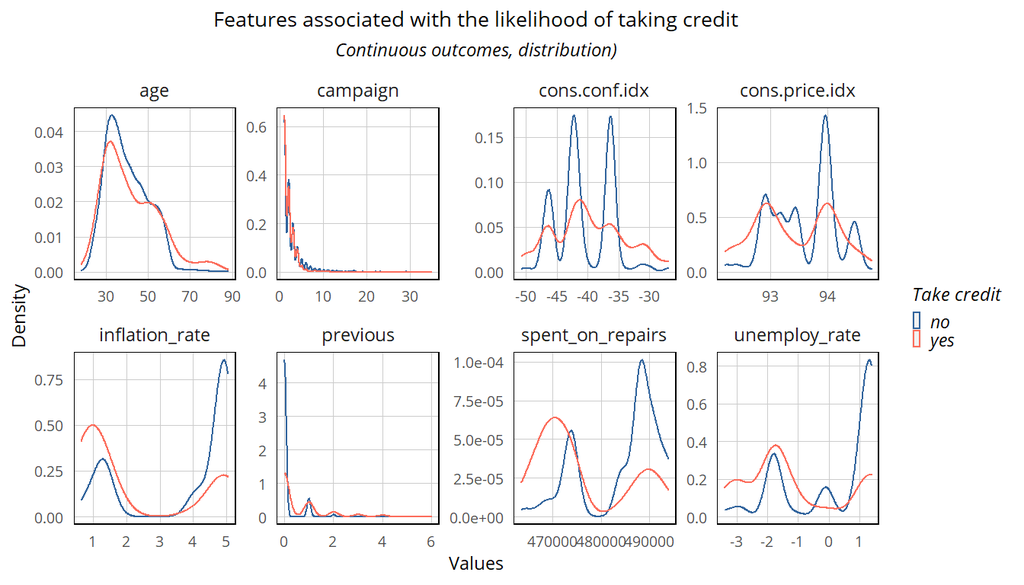

Figure 2.1

```r
# Read in data
takeCredit = read.csv(file.path(root.dir, '/Chapter6/housingSubsidy.csv'))

takeCredit = takeCredit %>%
  mutate(pdays = ifelse(pdays <= 10, 'Not more than 10 days', 'Other'),
         spent_on_repairs = spent_on_repairs * cons.price.idx)

## Continuous outcomes
continuousVars = c('age', 'campaign', 'previous', 'cons.conf.idx', 'cons.price.idx',
                   'inflation_rate', 'spent_on_repairs', 'unemploy_rate')
takeCredit %>%
  dplyr::select(continuousVars, y) %>%
  gather(variable, value, -y) %>%
  ggplot() +
  geom_density(aes(value, color = y), fill = 'transparent') +
  facet_wrap(~variable, scales = 'free', ncol = 4) +
  scale_color_manual(values = c(color3, color2),
                    name = 'Take credit') +
  labs(title = 'Features associated with the likelihood of taking credit',
       subtitle = 'Continuous outcomes, distribution)', x = 'Values',
       y = 'Density')+
  plotTheme2()
```

Figure 2.2 plots the *percentage* of taking credit or not taking credit corresponding to each value of the categorical features. Some values are associated with a greater likelihood of taking credit than others.

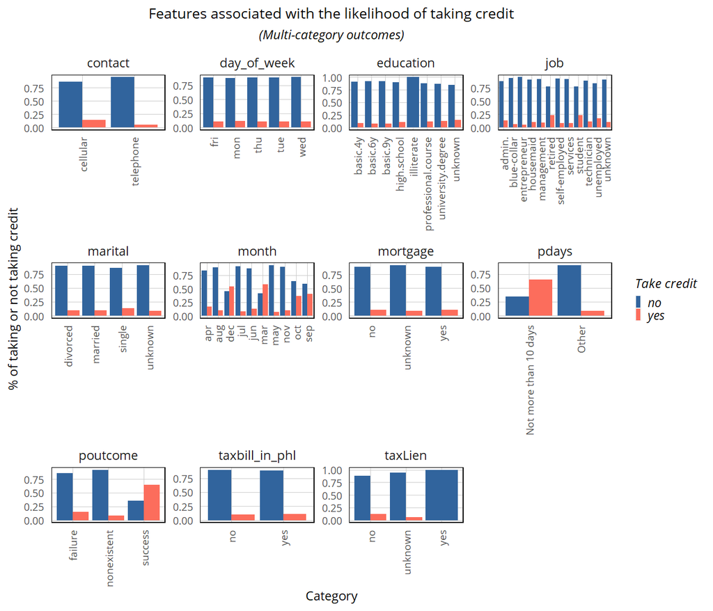

Figure 2.2

```r
multiClassVars = c('job', 'marital', 'education', 'taxLien', 'mortgage', 'poutcome',
                   'month', 'day_of_week', 'contact', 'taxbill_in_phl', 'pdays')
takeCredit %>%
  dplyr::select(multiClassVars, y) %>%
  gather(variable, value, -y) %>%
  group_by(variable, value) %>%
  mutate(number = n()) %>%
  ungroup() %>%
  group_by(variable, value, number, y) %>%
  summarize(number = mean(number), count = n()) %>%
  mutate(rate = count / number) %>%
  ggplot()+
  geom_bar(aes(value, rate, fill = y), position = 'dodge', stat = 'identity') +
  scale_fill_manual(values = c(color3, color2), name = 'Take credit') +
  facet_wrap(~variable, scales = 'free') +
  labs(x = 'Category', y = '% of taking or not taking credit',
       title = 'Features associated with the likelihood of taking credit',
       subtitle = '(Multi-category outcomes)') +
  plotTheme2() +
  theme(axis.text.x = element_text(angle = 90, size = 7, vjust = 0.5, hjust = 1))
```

## 3 Building a Logit model

A Logit model takes a dummy (two-category variable of either `TRUE` or `FALSE`) as the dependent variable. It classifies each observation into two categories - in this case, either *taking credit* or *not taking credit*. The objective of the model is to correctly classify those who will take credit as `TRUE` and, at the same time, not to falsely identify those who will not take credit. To test how good the model is, the data-set is separated into a training set containing 65% of the observations and a test set containing 35% of the observations. In the training set, a new column `cvID` is added to facilitate k-fold cross-validation later.

```r
# Add cv ID to takeCredit set
takeCredit = takeCredit %>%
  mutate(cvID = sample(50, size = nrow(takeCredit), replace = TRUE))

#-----First model-----
set.seed(3465)
trainSplit = createDataPartition(y = paste(takeCredit$job,
                                           takeCredit$education,
                                           takeCredit$y,
                                           takeCredit$taxLien),
                                 p = .65,
                                 list = F,
                                 times = 1)
takeCreditTrain = takeCredit[trainSplit,]
takeCreditTest = takeCredit[-trainSplit,]

regVars = takeCredit %>%
  dplyr::select(-cons.price.idx,-day_of_week, -y, -X,
                -y_numeric, -cvID) %>%
  names(.)

reg1 = glm(y_numeric ~ .,
           data = dplyr::select(takeCreditTrain, all_of(regVars), y_numeric),
           family = 'binomial'(link = 'logit'))
```

```r
stargazer(reg1,
          type = "html",
          single.row = TRUE,
          title = '<span style = "font-weight: normal"><center>Table 3.1</center></span>',
          dep.var.labels = "Taking credit")
```

Table 3.1

|  | *Dependent variable:* |
| --- | --- |
|  | Taking credit |
| age | 0.016* (0.008) |
| jobblue-collar | -0.402 (0.265) |
| jobentrepreneur | -0.281 (0.436) |
| jobhousemaid | 0.049 (0.441) |
| jobmanagement | -0.169 (0.282) |
| jobretired | -0.043 (0.347) |
| jobself-employed | -0.408 (0.392) |
| jobservices | -0.161 (0.283) |
| jobstudent | 0.015 (0.399) |
| jobtechnician | -0.073 (0.231) |
| jobunemployed | 0.289 (0.374) |
| jobunknown | -0.274 (0.689) |
| maritalmarried | 0.333 (0.245) |
| maritalsingle | 0.531* (0.279) |
| maritalunknown | 1.142 (1.129) |
| educationbasic.6y | 0.230 (0.384) |
| educationbasic.9y | 0.123 (0.308) |
| educationhigh.school | -0.007 (0.296) |
| educationilliterate | -11.818 (535.411) |
| educationprofessional.course | 0.156 (0.321) |
| educationuniversity.degree | 0.053 (0.295) |
| educationunknown | 0.266 (0.382) |
| taxLienunknown | 0.051 (0.198) |
| taxLienyes | -10.694 (535.411) |
| mortgageunknown | -0.672 (0.621) |
| mortgageyes | -0.123 (0.137) |
| taxbill_in_phlyes | 0.014 (0.187) |
| contacttelephone | -0.532** (0.235) |
| monthaug | -0.527 (0.406) |
| monthdec | 0.872 (0.673) |
| monthjul | 0.355 (0.348) |
| monthjun | 1.015*** (0.343) |
| monthmar | 1.146** (0.495) |
| monthmay | -0.446 (0.288) |
| monthnov | -0.515 (0.429) |
| monthoct | -0.582 (0.540) |
| monthsep | -0.437 (0.588) |
| campaign | -0.107** (0.042) |
| pdaysOther | -1.403** (0.620) |
| previous | 0.038 (0.177) |
| poutcomenonexistent | 0.268 (0.308) |
| poutcomesuccess | 0.598 (0.610) |
| unemploy_rate | 0.463** (0.197) |
| cons.conf.idx | 0.025 (0.027) |
| inflation_rate | 0.020 (0.431) |
| spent_on_repairs | -0.0002* (0.0001) |
| Constant | 80.072* (43.393) |
| Observations | 2,787 |
| Log Likelihood | -791.336 |
| Akaike Inf. Crit. | 1,676.673 |
| *Note:* | p<0.1; p<0.05; p<0.01 |

This model is then tested on the test set. The *predicted probability* of each observation in the test set is calculated, as opposed to the *observed outcome*. Figure 3.2 shows the distribution of predicted probabilities for those *taking credit* and those *not taking credit*. As exhibited by the distributions of probabilities, `reg1` is good at predicting *not taking credit*, but not good at predicting *taking credit*, as the probabilities do not cluster around 1.

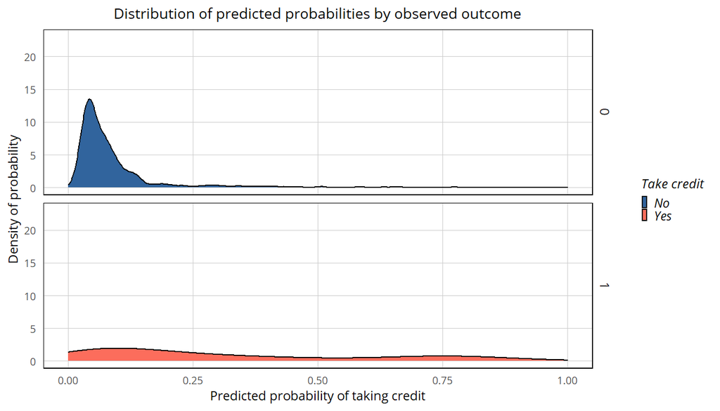

Figure 3.2

```r
testProbs = data.frame(observed = as.factor(takeCreditTest$y_numeric),
                       probs = predict(reg1, takeCreditTest, type = 'response'))

ggplot(testProbs, aes(x = probs, fill = as.factor(observed))) +
  geom_density() +
  facet_grid(observed ~ ., labeller = ) +
  scale_fill_manual(values = c(color3, color2), name = 'Take credit',
                    labels = c('No', 'Yes')) +
  labs(x = 'Predicted probability of taking credit',
       y = 'Density of probability',
       title = 'Distribution of predicted probabilities by observed outcome') +
  xlim(0, 1) +
  ylim(0, 23) +
  plotTheme2()
```

```r
testProbs = testProbs %>%
  mutate(predOutcome = as.factor(ifelse(testProbs$probs > 0.125, 1, 0)))
matrix1 = caret::confusionMatrix(testProbs$predOutcome, testProbs$observed, positive = '1')

as.data.frame(matrix1[['table']]) %>%
  kable(caption = '<center><small><small><small>Table 3.2</small></small></small></center>') %>%
  kable_classic(full_width = FALSE,
                  html_font = 'Open Sans',
                  position = 'center',
                  font_size = 9)
```

Table 3.2

| Prediction | Reference | Freq |
| --- | --- | --- |
| 0 | 0 | 1030 |
| 1 | 0 | 180 |
| 0 | 1 | 46 |
| 1 | 1 | 76 |

```r
cbind(
  Sensitivity = matrix1[['byClass']]['Sensitivity'],
  Specificity = matrix1[['byClass']]['Specificity'],
  AUC = pROC::auc(testProbs$observed, testProbs$probs)
) %>% as.data.frame() %>%
  gather(Metric, Value) %>%
  kable(caption = '<center><small><small><small>Table 3.3</small></small></small></center>') %>%
  kable_classic(full_width = FALSE,
                  html_font = 'Open Sans',
                  position = 'center',
                  font_size = 10)
```

Table 3.3

| Metric | Value |
| --- | --- |
| Sensitivity | 0.6229508 |
| Specificity | 0.8512397 |
| AUC | 0.7833491 |

## 4 Feature engineering

```r
takeCredit2 = takeCredit %>%
  mutate(month = ifelse(month %in% c('dec', 'mar'), 'Dec or Mar',
                        ifelse(month %in% c('oct', 'sep'), 'Oct or Sep', 'other')),
         job = ifelse(job %in% c('retired', 'student', 'unemployed',
                                 'blue-collar', 'entrepreneur'),
                      job, 'other'),
         age = ifelse(between(age, 30, 48), '30 to 48 years', 'other'),
         spent_on_repairs = ifelse(spent_on_repairs <= 469000, '469,000 or less',
                                   ifelse(spent_on_repairs >= 483000,
                                          '483000 or more', 'other')),
         unemploy_rate = ifelse(unemploy_rate < -0.75, '-0.75 or less',
                                ifelse(unemploy_rate > 1, '1 or more', 'other')),
         previous = case_when(previous == 0 ~ '0',
                              previous == 1 ~ '1',
                              previous > 1 ~ 'More than 1')
         )
```

```r
#-----Second model-----
set.seed(3567)
trainSplit2 = createDataPartition(y = paste(takeCredit2$job,
                                           takeCredit2$education,
                                           takeCredit2$y,
                                           takeCredit2$taxLien),
                                 p = .65,
                                 list = F,
                                 times = 1)

takeCreditTrain2 = takeCredit2[trainSplit2,]
takeCreditTest2 = takeCredit2[-trainSplit2,]

reg2 = glm(y_numeric ~ .,
           data = dplyr::select(takeCreditTrain2, all_of(regVars), y_numeric),
           family = 'binomial'(link = 'logit'))
```

After feature engineering, the summary for the second model is shown in Table 4.1.

```r
stargazer(reg2,
          type = "html",
          single.row = TRUE,
          title = '<span style = "font-weight: normal"><center>Table 4.1</center></span>',
          dep.var.labels = "Taking credit")
```

Table 4.1

|  | *Dependent variable:* |
| --- | --- |
|  | Taking credit |
| ageother | -0.016 (0.148) |
| jobentrepreneur | 0.060 (0.449) |
| jobother | 0.227 (0.226) |
| jobretired | 0.660** (0.333) |
| jobstudent | 0.592 (0.412) |
| jobunemployed | 0.659* (0.379) |
| maritalmarried | 0.183 (0.233) |
| maritalsingle | 0.237 (0.252) |
| maritalunknown | -12.226 (341.280) |
| educationbasic.6y | 0.200 (0.382) |
| educationbasic.9y | -0.046 (0.299) |
| educationhigh.school | -0.158 (0.281) |
| educationilliterate | -13.530 (882.744) |
| educationprofessional.course | 0.155 (0.297) |
| educationuniversity.degree | 0.031 (0.276) |
| educationunknown | 0.214 (0.379) |
| taxLienunknown | 0.051 (0.197) |
| taxLienyes | -11.609 (882.744) |
| mortgageunknown | -0.033 (0.481) |
| mortgageyes | -0.040 (0.138) |
| taxbill_in_phlyes | 0.167 (0.187) |
| contacttelephone | -0.490*** (0.183) |
| monthOct or Sep | -1.402*** (0.408) |
| monthother | -1.737*** (0.368) |
| campaign | -0.076* (0.040) |
| pdaysOther | -0.158 (0.700) |
| previous1 | -0.559** (0.222) |
| previousMore than 1 | -0.160 (0.333) |
| poutcomenonexistent |  |
| poutcomesuccess | 1.857*** (0.701) |
| unemploy_rate1 or more | -8.134 (882.745) |
| unemploy_rateother | -9.927 (882.744) |
| cons.conf.idx | 0.015 (0.025) |
| inflation_rate | -2.171*** (0.549) |
| spent_on_repairs483000 or more | 15.756 (882.744) |
| spent_on_repairsother | 0.745* (0.394) |
| Constant | 2.623** (1.128) |
| Observations | 2,738 |
| Log Likelihood | -796.884 |
| Akaike Inf. Crit. | 1,665.768 |
| *Note:* | p<0.1; p<0.05; p<0.01 |

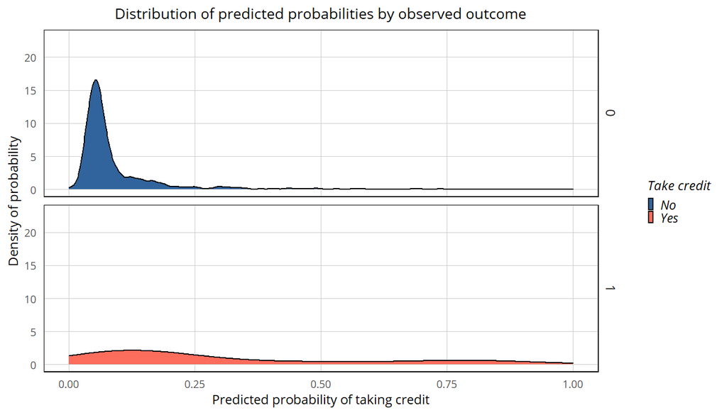

Figure 4.1

```r
testProbs2 = data.frame(observed = as.factor(takeCreditTest2$y_numeric),
                        probs = predict(reg2, takeCreditTest2, type = 'response'))

ggplot(testProbs2, aes(x = probs, fill = as.factor(observed))) +
  geom_density() +
  facet_grid(observed ~ ., labeller = ) +
  scale_fill_manual(values = c(color3, color2), name = 'Take credit',
                    labels = c('No', 'Yes')) +
  labs(x = 'Predicted probability of taking credit',
       y = 'Density of probability',
       title = 'Distribution of predicted probabilities by observed outcome') +
  xlim(0, 1) +
  ylim(0, 23) +
  plotTheme2()
```

```r
testProbs2 = testProbs2 %>%
  mutate(predOutcome = as.factor(ifelse(testProbs2$probs > 0.11, 1, 0)))

matrix2 = caret::confusionMatrix(testProbs2$predOutcome, testProbs2$observed, positive = '1')

as.data.frame(matrix2[['table']]) %>%
  kable(caption = '<center><small><small><small>Table 4.2</small></small></small></center>') %>%
  kable_classic(full_width = FALSE,
                  html_font = 'Open Sans',
                  position = 'center',
                  font_size = 9)
```

Table 4.2

| Prediction | Reference | Freq |
| --- | --- | --- |
| 0 | 0 | 1008 |
| 1 | 0 | 239 |
| 0 | 1 | 39 |
| 1 | 1 | 95 |

```r
cbind(
  Sensitivity = matrix2[['byClass']]['Sensitivity'],
  Specificity = matrix2[['byClass']]['Specificity'],
  AUC = pROC::auc(testProbs2$observed, testProbs2$probs)
) %>% as.data.frame() %>%
  gather(Metric, Value) %>%
  kable(caption = '<center><small><small><small>Table 4.3</small></small></small></center>') %>%
  kable_classic(full_width = FALSE,
                  html_font = 'Open Sans',
                  position = 'center',
                  font_size = 10)
```

Table 4.3

| Metric | Value |
| --- | --- |
| Sensitivity | 0.7089552 |
| Specificity | 0.8083400 |
| AUC | 0.7925409 |

## 5 The ROC curves

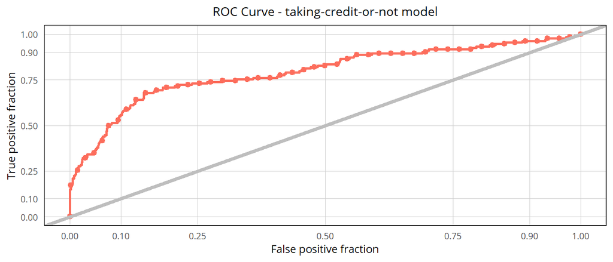

Figure 5.1

```r
ggplot(testProbs2, aes(d = as.numeric(testProbs2$observed), m = probs)) +
  geom_roc(n.cuts = 50, labels = FALSE, colour = color2) +
  style_roc(theme = theme_grey) +
  geom_abline(slope = 1, intercept = 0, size = 1.5, color = 'grey') +
  labs(title = "ROC Curve - taking-credit-or-not model") +
  plotTheme2()
```

## 6 Cross-validation

```r
# K-fold cross-validation for this model
crossValidate = function(dataset, id, dependentVariable, indVariables, threshold){
  sensitivity = list()
  specificity = list()
  AUC = list()
  cvIDList = unique(dataset[[id]])
  for (i in cvIDList) {
    thisFold = i
    cat("This hold out fold is", thisFold, "\n")
    fold.train = filter(dataset, dataset[[id]] != thisFold) %>% as.data.frame() %>%
      dplyr::select(id, indVariables, dependentVariable)
    fold.test = filter(dataset, dataset[[id]] == thisFold) %>% as.data.frame() %>%
      dplyr::select(id, indVariables, dependentVariable)
    reg =
      glm(paste0(dependentVariable, '~.'), family = "binomial"(link = 'logit'),
          data = fold.train %>% dplyr::select(-id))
    testProbs = data.frame(observed = as.factor(fold.test[[dependentVariable]]),
                           probs = predict(reg, fold.test, type = 'response'))
    testProbs = testProbs %>%
      mutate(predOutcome = as.factor(ifelse(testProbs$probs >= threshold, 1, 0)))
    matrix = caret::confusionMatrix(
      testProbs$predOutcome, testProbs$observed, positive = '1')
    sensitivity = append(sensitivity,
                         as.numeric(matrix[['byClass']]['Sensitivity']))
    specificity = append(specificity,
                         as.numeric(matrix[['byClass']]['Specificity']))
    AUC = append(AUC,
                 as.numeric(pROC::auc(testProbs$observed, testProbs$probs)))
  }
  outTable = cbind(sensitivity %>% as.numeric(),
                   specificity %>% as.numeric(),
                   AUC %>% as.numeric()) %>% as.data.frame
  names(outTable) = c('sensitivity', 'specificity', 'AUC')
  row.names(outTable) = NULL
  return(outTable)
}

# Merge feature values to avoid new levels in the test set
# Data set for the first model
takeCredit$job[takeCredit$job %in% c('unknown', 'housemaid', 'entrepreneur')] = 'other'
takeCredit$education[takeCredit$education == 'illiterate'] = 'unknown'
takeCredit$taxLien[takeCredit$taxLien == 'yes'] = 'unknown'

# Data set for the second model
takeCredit2$job[takeCredit2$job %in% c('unknown', 'housemaid', 'entrepreneur')] = 'other'
takeCredit2$education[takeCredit2$education == 'illiterate'] = 'unknown'
takeCredit2$taxLien[takeCredit2$taxLien == 'yes'] = 'unknown'

crossValidation1 = crossValidate(
  dataset = takeCredit,
  id = 'cvID',
  dependentVariable = 'y_numeric',
  indVariables = regVars,
  threshold = 0.125)

crossValidation2 = crossValidate(
  dataset = takeCredit2,
  id = 'cvID',
  dependentVariable = 'y_numeric',
  indVariables = regVars,
  threshold = 0.11)
```

```r
rbind(
  c(Model = 'First model', Threshold = '12.5%', crossValidation1 %>% summarize_all(mean) %>% round(., 2)),
  c(Model = 'Second model', Threshold = '11%', crossValidation2 %>% summarize_all(mean) %>% round(., 2))
) %>%
  kable(caption = '<center><small><small><small>Table 6.1</small></small></small></center>',
        digits = 2) %>%
  kable_classic(full_width = FALSE,
                  html_font = 'Open Sans',
                  position = 'center',
                  font_size = 10) %>%
  footnote('These are not optimal thresholds; the optimal threshold will be explored in the 7th section.')
```

Table 6.1

| Model | Threshold | sensitivity | specificity | AUC |
| --- | --- | --- | --- | --- |
| First model | 12.5% | 0.6 | 0.86 | 0.76 |
| Second model | 11% | 0.65 | 0.79 | 0.76 |

Note:  
These are not optimal thresholds; the optimal threshold will be explored in the 7th section.

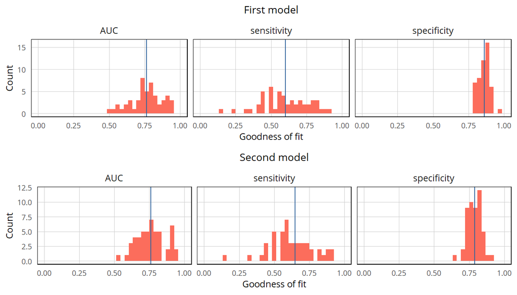

Figure 6.1

```r
cvPlots1 =
  crossValidation1 %>%
  gather(metric, value) %>%
  group_by(metric) %>%
  mutate(mean = mean(value)) %>%
  ungroup() %>%
  ggplot(aes(value)) +
  geom_histogram(bins = 35, fill = color2) +
  facet_wrap(~metric) +
  geom_vline(aes(xintercept  = mean), color = color3,
             size = .5) +
  scale_x_continuous(limits = c(0, 1)) +
  labs(x = 'Goodness of fit', y = 'Count',
       title = 'First model') +
  plotTheme2()


cvPlots2 =
  crossValidation2 %>%
  gather(metric, value) %>%
  group_by(metric) %>%
  mutate(mean = mean(value)) %>%
  ungroup() %>%
  ggplot(aes(value)) +
  geom_histogram(bins = 35, fill = color2) +
  facet_wrap(~metric) +
  geom_vline(aes(xintercept  = mean), color = color3,
             size = .5) +
  scale_x_continuous(limits = c(0, 1)) +
  labs(x = 'Goodness of fit', y = 'Count',
       title = 'Second model') +
  plotTheme2()

grid.arrange(ncol = 1, cvPlots1, cvPlots2)
```

## 7 Cost-benefit calculations

In this section, I develop a cost-benefit analysis for each scenario in the confusion matrix. Here, costs and benefits are calculated in terms of *aggregate public good* rather than for the Emil City government or the HCD. Therefore, the *costs* includes marketing costs and home repair costs, and the benefits are the premium in home values after home repairs.

When using the model to target those home owners who are likely to take credit, marketing resources are allocated those marked *positive* by the model, hoping that they will uptake the program. However, among those home owners willing to get started, only 25% complete the process and take credit in the end. Therefore, the cost-benefit equations are laid out as follows:

1. True Positive. These are the home owners that you *correctly predict* to be willing to uptake the program. Marketing resources are allocated to them and get responded to positively, but only 25% of them complete the process to get the credit. For those completing the process and taking credit in the end, the cost is the $2,850 marketing cost and the $5,000 tax credit, and the benefit is the total $66,000 premium in house prices. The total net revenue is $66,000 - $2,850 - $5,000 = $58,150. For those not completing the process, the cost is the $2,850 marketing cost.
2. False Positive. These are the home owners that you *incorrectly predict* to be willing to uptake the program. Marketing resources are allocated to them, but they do not participate. The cost of this situation is $2,850.
3. True Negative and False Negative. These are the home owners that the model suggests will not take the credit. On this basis, no campaigning effort is targeted at them, and the the cost/benefit for these situations is zero.

Figure 7.1 plot the benefit/cost outcomes for each scenario in the confusion matrix. As the threshold increases, the benefits associated with TP drops while the the cost associated with FP also declines.

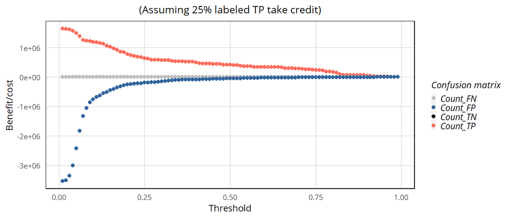

Figure 7.1

```r
#-----Calculate-----

whichThreshold_25_pct =
  iterateThresholds(
    data = testProbs2,
    observedClass = observed,
    predictedProbs = probs
  ) %>%
  dplyr::select(starts_with('Count'), Threshold) %>%
  gather(Variable, Count, -Threshold) %>%
  mutate(Revenue =
           case_when(Variable == 'Count_TN' ~ 0,
                     Variable == 'Count_TP' ~ Count * 58150 * 0.25 + Count * (-2850) * 0.75,
                     Variable == 'Count_FN' ~ 0,
                     Variable == 'Count_FP' ~ Count * (-2850)),
         Cost =
           case_when(Variable == 'Count_TN' ~ 0,
                     Variable == 'Count_TP' ~ Count * 7850 * 0.25 + Count * 2850 * 0.75,
                     Variable == 'Count_FN' ~ 0,
                     Variable == 'Count_FP' ~ Count * (2850)),
         Credits =
           case_when(Variable == 'Count_TP' ~ Count * 0.25,
                     TRUE ~ 0))

#-----Plot-----

whichThreshold_25_pct %>%
  #filter(., Variable != 'Count_FN') %>%
  ggplot(., aes(Threshold, Revenue, color = Variable)) +
  geom_point() +
  scale_color_manual(values = c('grey', color3, 'black', color2),
                     name = 'Confusion matrix') +
  labs(title = '(Assuming 25% labeled TP take credit)',
       y = 'Benefit/cost') +
  plotTheme2()
```

The *total net revenue* is the most straightforward goal when choosing a threshold. However, in the context of public policy, it is not the sole goal being optimized for. When reaching out for potential home owners, the budget for the marketing and tax credits is often limited, and even fixed, and the revenue should be compared on the basis of *comparable costs*. Thus, the *net revenue per unit cost* is also calculated.

Apart from the explicit costs or benefits, *equity* is also an important goal for a public policy. This requires that the program policy should reach out to as wide the range of beneficiaries as possible, rather than being overly concentrated on a small group of people of distinct characteristics. In the case of Logit algorithms, *the cutting threshold for policy distribution should not be too high*.

Figure 7.2 plots the total net revenue, net revenue per unit cost, and the total number of credit-taking home owners as a function to the cutting threshold.

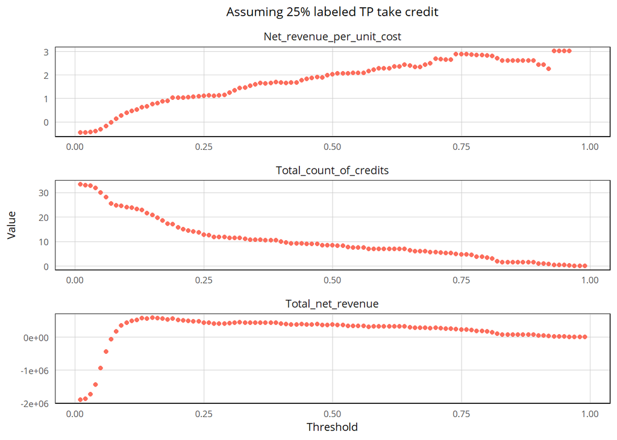

Figure 7.2

```r
whichThreshold_revenue_25_pct =
  whichThreshold_25_pct %>%
  group_by(Threshold) %>%
  summarise(Total_net_revenue = sum(Revenue),
            Total_cost = sum(Cost),
            Total_count_of_credits = sum(Credits),
            Net_revenue_per_unit_cost = Total_net_revenue / Total_cost)

whichThreshold_revenue_25_pct %>%
  dplyr::select(-Total_cost) %>%
  gather(Variable, Value, -Threshold) %>%
  ggplot() +
  geom_point(aes(x = Threshold, y = Value), color = color2) +
  facet_wrap(~Variable, scales = 'free', ncol = 1)+
  labs(title = 'Assuming 25% labeled TP take credit') +
  plotTheme2()
```

In terms of total net revenue, the optimal cutting threshold is 16%. At this threshold, the net revenue per unit cost is not at the highest, but sufficient. Continuing to increase the threshold would increase revenue per fixed cost, but would narrow the scope of beneficiaries of the program. Therefore, I set the optimal threshold at 16%.

Table 7.1 summarizes the total net revenue, net revenue per unit cost, and total number of credit-taking home owners when using the optimal threshold (16%) and the reference threshold (50%). Comparable to the reference threshold, the optimal threshold significantly increases the overall revenue and the number of people taking credit.

```r
whichThreshold_revenue_25_pct %>%
  dplyr::select(Threshold, Total_net_revenue, Total_cost, Net_revenue_per_unit_cost, Total_count_of_credits) %>%
  mutate(Net_revenue_per_unit_cost = round(Net_revenue_per_unit_cost, 2),
         Total_count_of_credits = round(Total_count_of_credits, 0)) %>%
  filter(., Threshold %in% c(0.16, 0.5)) %>%
  kable(caption = '<center><small><small><small>Table 7.1</small></small></small></center>',
        ) %>%
  kable_classic(full_width = FALSE,
                  html_font = 'Open Sans',
                  position = 'center',
                  font_size = 10)
```

Table 7.1

| Threshold | Total_net_revenue | Total_cost | Net_revenue_per_unit_cost | Total_count_of_credits |
| --- | --- | --- | --- | --- |
| 0.16 | 574900 | 728600 | 0.79 | 20 |
| 0.50 | 376000 | 185000 | 2.03 | 8 |

```r
testProbs2 = testProbs2 %>%
  mutate(predOutcome = as.factor(ifelse(testProbs2$probs > 0.16, 1, 0)))

testProbs2 %>%
  count(predOutcome, observed) %>%
  summarize(True_Negative = sum(n[predOutcome==0 & observed==0]),
            True_Positive = sum(n[predOutcome==1 & observed==1]),
            False_Negative = sum(n[predOutcome==0 & observed==1]),
            False_Positive = sum(n[predOutcome==1 & observed==0])) %>%
  gather(Variable, Count) %>%
  mutate(Revenue =
           case_when(Variable == 'True_Negative' ~ 0,
                     Variable == 'True_Positive' ~ Count * (58150) * 0.25 +
                       Count * 0.75 * (-2850),
                     Variable == 'False_Negative' ~ 0,
                     Variable == 'False_Positive' ~ Count * (-2850))) %>%
  bind_cols(data.frame(Description = c(
    'Predicted correctly not taking credit and did not campaign',
    'Predicted correctly taking credit, campaigned, and 25% finally take credit',
    'Predicted not taking credit, when the owners in fact would',
    'Predicted taking credit, campaigned, but the owners did not participate'
  ))) %>%
  kable(caption = '<center><small><small><small>Table 7.2</small></small></small></center>') %>%
  kable_classic(full_width = FALSE,
                  html_font = 'Open Sans',
                  position = 'center',
                  font_size = 10) %>%
  footnote('Assuming 25% labeled as TP take credit')
```

Table 7.2

| Variable | Count | Revenue | Description |
| --- | --- | --- | --- |
| True_Negative | 1105 | 0 | Predicted correctly not taking credit and did not campaign |
| True_Positive | 79 | 979600 | Predicted correctly taking credit, campaigned, and 25% finally take credit |
| False_Negative | 55 | 0 | Predicted not taking credit, when the owners in fact would |
| False_Positive | 142 | -404700 | Predicted taking credit, campaigned, but the owners did not participate |

Note:  
Assuming 25% labeled as TP take credit

## 8 Conclusions

Apart from feature engineering, a better model would rely on finding new features that better account for whether a home owner will participate in this program or not. Finally, the current model assumes that those unlikely home owners cannot persuaded into participation. However, it is reasonable to assume that a good marketing material *can* change a home owner’s mind. The HCD should ensure that the marketing materials be clear, concise, and persuasive, in order to obtain a better response rate.